# gis assignment for CASA

Lingwei ZHENG

2021/1/9

## Firstly, set the library

```r
library(broom)
library(car)
library(chron)
library(corrr)
library(crosstalk)
library(fs)
library(fpc)
library(geojson)
library(geojsonio)
library(ggplot2)
library(ggthemes)
library(GISTools)
library(GWmodel)
library(here)
library(janitor)
library(lubridate)
library(maptools)
library(mapview)
library(plotly)
library(qpcR)
library(raster)
library(rgdal)
library(rgeos)
library(scales)
library(sf)
library(stringr)
library(sp)
library(spatstat)
library(spatialreg)
library(spdep)
library(spgwr)
library(tidyverse)
library(tmap)
library(tmaptools)
```

## Import the main dataset

load the bike share dataset and map

```r
##First, get the London Borough Boundaries
temp <- tempfile(fileext = ".zip")
download.file("https://github.com/Lingweiz1998/FPgis/raw/master/data/201909-citibike-tripdata.zip",
              temp)
out <- unzip(temp, exdir = tempdir())
nb <- read_csv(out,
               locale = locale(encoding = "utf-8"))
nycd <- st_read("https://services5.arcgis.com/GfwWNkhOj9bNBqoJ/arcgis/rest/services/NYC_Community_Districts/FeatureServer/0/query?where=1=1&outFields=*&outSR=4326&f=pgeojson")
```

## clean the data and select the specific day (sep 10th, 2019)

```r
## clean name
colnames(nycd) <- colnames(nycd) %>%
  str_to_lower() %>%
  str_replace_all(" ", "_")
colnames(nb) <- colnames(nb) %>%
  str_to_lower() %>%
  str_replace_all(" ", "_")
# choose columns
nb <- nb %>%
  dplyr::select(starttime,start_station_latitude,start_station_longitude,end_station_latitude,end_station_longitude)

colnames(nycd)
```

```
## [1] "objectid"      "borocd"        "shape__area"   "shape__length"
## [5] "geometry"
```

```r
colnames(nb)
```

```
## [1] "starttime"               "start_station_latitude"
## [3] "start_station_longitude" "end_station_latitude"
## [5] "end_station_longitude"
```

```r
# filter the target day
nbday <-nb %>%
  filter(starttime >= ymd_hms('20190910 00:00:00') & starttime <= ymd_hms('20190911 00:00:00'))
```

# Time series Analysis

Now, let us go to the first process of our analysis, we first use the ggplot2 to visualize the frequency plot of the bicycle sharing use.

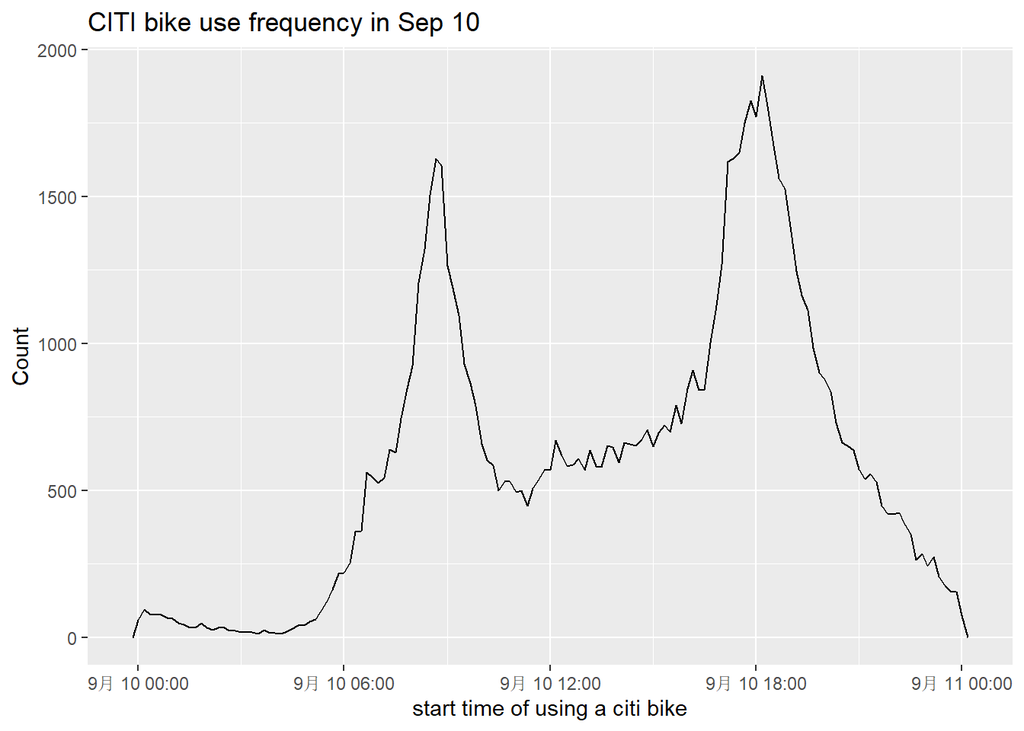

```r
## Time Series Analysis by ggplot2
nbday %>%
  ggplot(aes(starttime)) +
  geom_freqpoly(binwidth = 600)+
  xlab("start time of using a citi bike") +
  ylab("Count") +
  ggtitle("CITI bike use frequency in Sep 10")
```

Let’s pick some period of time for next analysis.

```r
nbmorning <- nbday %>%
  filter(starttime >= ymd_hms('20190910 07:00:00') & starttime <= ymd_hms('20190911 11:00:00'))
nbnight <- nbday %>%
  filter(starttime >= ymd_hms('20190910 16:00:00') & starttime <= ymd_hms('20190911 20:00:00'))
```

## limit the research area

Let’s do something with our map scope, this map contains all the district in NYC, but we don’t need all of them. By directly looking at the Citi Bike webpage map, I found the community districts that contain bike station. Let’s filter them!

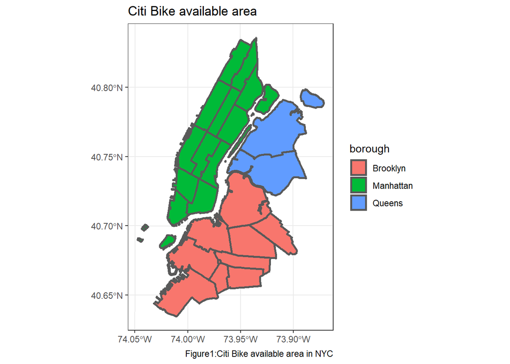

```r
CDMap1boro <- nycd %>%
  filter(borocd >= "355" & borocd <= "402" & borocd != "356"| borocd >= "301" & borocd <= "309" & borocd != "305"| borocd <= "164" & borocd != "112" ) %>%
  `colnames<-`(str_to_lower(colnames(nycd)))

CDMap1boro <- CDMap1boro %>%
  mutate(borough = case_when(borocd >= 400 ~ "Queens",
                             borocd >= 300 & borocd < 400 ~ "Brooklyn",
                             TRUE ~ "Manhattan"))

##Change CRS for boro shp
CDMap1boro <- CDMap1boro %>%
  st_transform(.,crs = "epsg:2263")

##compare data in map
ggplot(CDMap1boro) +
  aes(fill = borough) +
  geom_sf(size = 1L) +
  scale_fill_hue() +
  labs(title = "Citi Bike available area", caption = "Figure1:Citi Bike available area in NYC") +
  theme_bw()
```

We can make the df of different time period to compare them in the following steps.

let’s also limit the bike data in this scope to ensure that no outliers. (Because Jersey City also has Citi Bike and we don’t want to consider this area)

```r
## st to sf
nbday_start <- st_as_sf(nbday, coords = c("start_station_longitude", "start_station_latitude"), crs = "WGS84")
nbday_end <- st_as_sf(nbday, coords = c("end_station_longitude", "end_station_latitude"), crs = "WGS84")
nycmorningstart <- st_as_sf(nbmorning, coords = c("start_station_longitude", "start_station_latitude"),crs = "WGS84")
nycmorningend <- st_as_sf(nbmorning, coords = c("end_station_longitude", "end_station_latitude"),crs = "WGS84")
nycnightstart <- st_as_sf(nbnight, coords = c("start_station_longitude", "start_station_latitude"), crs = "WGS84")
nycnightend <- st_as_sf(nbnight, coords = c("end_station_longitude", "end_station_latitude"),crs = "WGS84")
nbday_start <- nbday_start %>% st_transform(.,crs="epsg:2263")
nbday_end <- nbday_end %>% st_transform(.,crs="epsg:2263")
nycmorningstart <- nycmorningstart %>% st_transform(.,crs="epsg:2263")
nycmorningend <- nycmorningend %>% st_transform(.,crs="epsg:2263")
nycnightstart <- nycnightstart %>% st_transform(.,crs="epsg:2263")
nycnightend <- nycnightend %>% st_transform(.,crs="epsg:2263")

##limit the data in the Manhattan boro
nbday_start <- nbday_start[CDMap1boro,]
nbday_end <- nbday_end[CDMap1boro,]
nycmorningstart <- nycmorningstart[CDMap1boro,]
nycmorningend <- nycmorningend[CDMap1boro,]
nycnightstart <- nycnightstart[CDMap1boro,]
nycnightend <- nycnightend[CDMap1boro,]
```

# KDE

We can now do the kernel density estimate plot by the following codes.

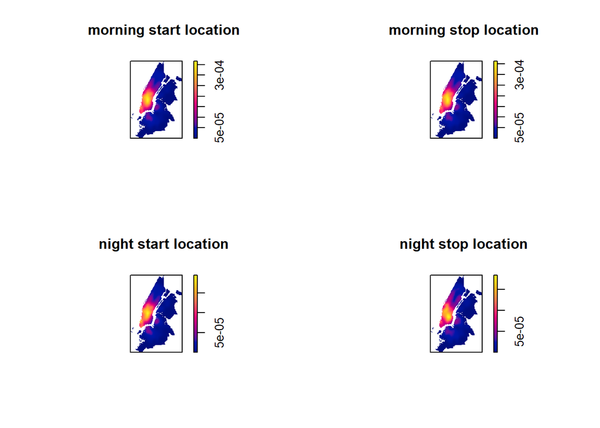

```r
#now set a window as the borough boundary
window <- as.owin(CDMap1boro)
#plot(window)
#create a ppp object
nbday_start_sub<- nbday_start %>%
  as(., 'Spatial')
nbday_end_sub<- nbday_end %>%
  as(., 'Spatial')
nycmorningstart_sub<- nycmorningstart %>%
  as(., 'Spatial')
nycmorningend_sub<- nycmorningend %>%
  as(., 'Spatial')
nycnightstart_sub<- nycnightstart %>%
  as(., 'Spatial')
nycnightend_sub<- nycnightend %>%
  as(., 'Spatial')

nbday_start_sub.ppp <- ppp(x=nbday_start_sub@coords[,1],
                              y=nbday_start_sub@coords[,2],
                              window=window)
nbday_end_sub.ppp <- ppp(x=nbday_end_sub@coords[,1],
                           y=nbday_end_sub@coords[,2],
                           window=window)
nycmorningstart_sub.ppp <- ppp(x=nycmorningstart_sub@coords[,1],
                           y=nycmorningstart_sub@coords[,2],
                           window=window)
nycmorningend_sub.ppp <- ppp(x=nycmorningend_sub@coords[,1],
                           y=nycmorningend_sub@coords[,2],
                           window=window)
nycnightstart_sub.ppp <- ppp(x=nycnightstart_sub@coords[,1],
                           y=nycnightstart_sub@coords[,2],
                           window=window)
nycnightend_sub.ppp <- ppp(x=nycnightend_sub@coords[,1],
                           y=nycnightend_sub@coords[,2],
                           window=window)
#Kernel Density Estimation
par(mfrow=c(2,2)) #plot to 2 by 2 array
nycmorningstart_sub.ppp %>%
  density(., sigma=1500) %>%
  plot(main="morning start location")

nycmorningend_sub.ppp %>%
  density(., sigma=1500) %>%
  plot(main="morning stop location")

nycnightstart_sub.ppp %>%
  density(., sigma=1500) %>%
  plot(main="night start location")

nycnightend_sub.ppp %>%
  density(., sigma=1500) %>%
  plot(main="night stop location")
```

```r
par(mfrow=c(1,1)) #set back to default
```

## Local Moran’s I

for the all day pattern, We can use LM to test the spatial autocorrelation, this is another good way to see the clustering. let’s calculate the density first:

```r
points_sf_joined <- CDMap1boro%>%
  st_join(nbday_start)%>%
  add_count(borocd)%>%
  janitor::clean_names()%>%
  #calculate area
  mutate(area=st_area(.))%>%
  #then density of the points per ward
  mutate(density=n/area)%>%
  #select density and some other variables
  dplyr::select(density, borocd, n)
```

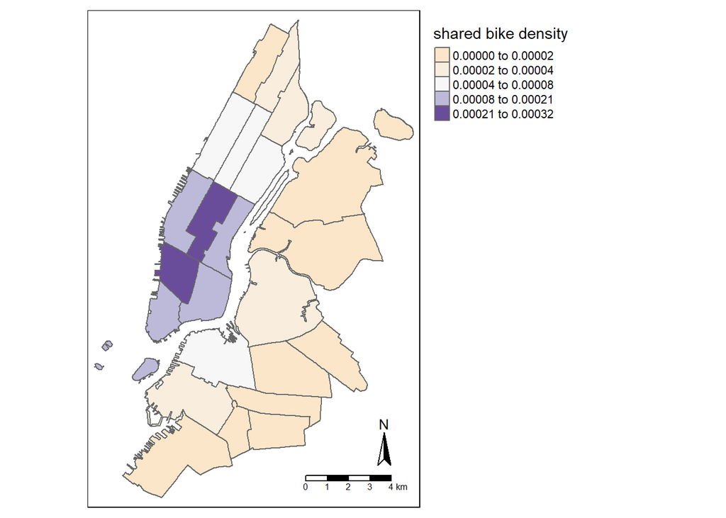

```r
points_sf_joined<- points_sf_joined %>%
  group_by(borocd) %>%
  summarise(density = first(density),
            borocd= first(borocd),
            count= first(n))

tmap_mode("plot")
tm_shape(points_sf_joined) +
  tm_polygons("density",
              style="jenks",
              palette="PuOr",
              midpoint=NA,
              popup.vars=c("borocd", "density"),
              title="shared bike density")+
  tm_compass(position = c("right", "bottom"))+
  tm_scale_bar(position = c("right", "bottom"))+
  tm_layout(legend.outside = TRUE)
```

```r
# standerdized the data for regression analysis
points_sf_joined$density_scaled <- scale(points_sf_joined$density,center = FALSE, scale = TRUE)
```

Now we can output the local moran’s i or the Gi* to see the autocorrelation.

```r
#First calculate the centroids of all Wards in London

coordsW <- points_sf_joined%>%
  st_centroid()%>%
  st_geometry()
```

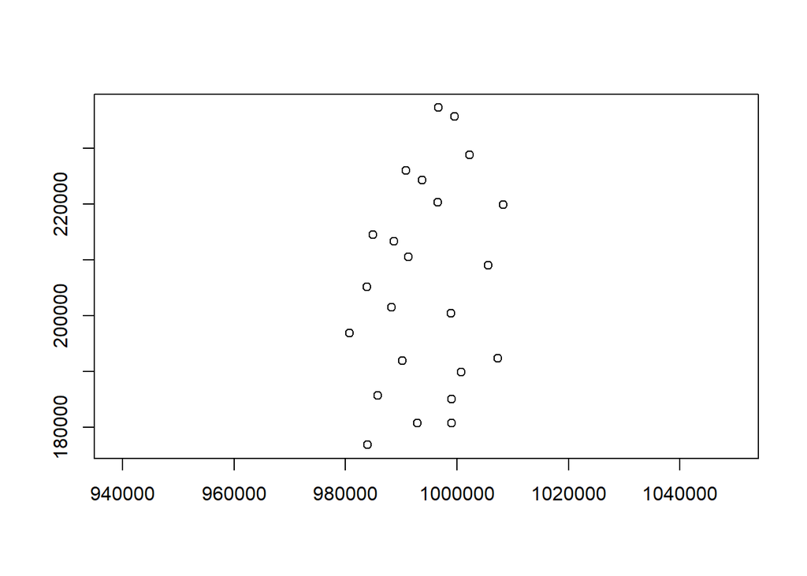

```r
plot(coordsW,axes=TRUE)
```

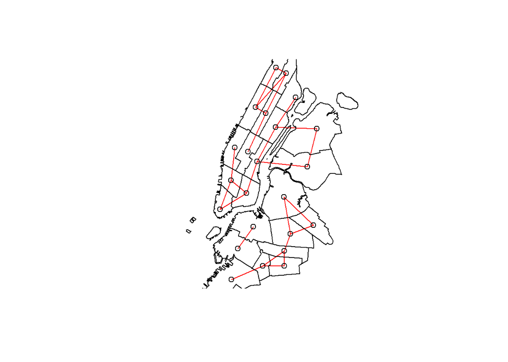

```r
#create a neighbours list

nyccd_nb <- points_sf_joined %>%
  poly2nb(., queen=T)

#plot them
plot(nyccd_nb, st_geometry(coordsW), col="red")
#add a map underneath
plot(points_sf_joined$geometry, add=T)
```

```r
#create a spatial weights object from these weights
nyccd.nb <- nyccd_nb %>%
  nb2listw(., style="C")

head(nyccd.nb$neighbours)
```

```
## [[1]]
## [1] 2 3
##
## [[2]]
## [1] 1 3 4
##
## [[3]]
## [1] 1 2 6
##
## [[4]]
## [1] 2
##
## [[5]]
## [1] 12
##
## [[6]]
## [1]  3  8 23
```

```r
## Testing
I_CD_Global_Density  <- points_sf_joined %>%
  pull(density) %>%
  as.vector()%>%
  moran.test(., nyccd.nb)
I_CD_Global_Density
```

```
##
##  Moran I test under randomisation
##
## data:  .
## weights: nyccd.nb
##
## Moran I statistic standard deviate = 3.2514, p-value = 0.0005743
## alternative hypothesis: greater
## sample estimates:
## Moran I statistic       Expectation          Variance
##        0.55452795       -0.04545455        0.03405235
```

```r
C_CD_Global_Density <-
  points_sf_joined %>%
  pull(density) %>%
  as.vector()%>%
  geary.test(., nyccd.nb)
C_CD_Global_Density
```

```
##
##  Geary C test under randomisation
##
## data:  .
## weights: nyccd.nb
##
## Geary C statistic standard deviate = 3.0863, p-value = 0.001013
## alternative hypothesis: Expectation greater than statistic
## sample estimates:
## Geary C statistic       Expectation          Variance
##        0.33015851        1.00000000        0.04710605
```

```r
G_CD_Global_Density <-
  points_sf_joined %>%
  pull(density) %>%
  as.vector()%>%
  globalG.test(., nyccd.nb)
G_CD_Global_Density
```

```
##
##  Getis-Ord global G statistic
##
## data:  .
## weights: nyccd.nb
##
## standard deviate = 2.6277, p-value = 0.004298
## alternative hypothesis: greater
## sample estimates:
## Global G statistic        Expectation           Variance
##       0.0858809640       0.0454545455       0.0002366903
```

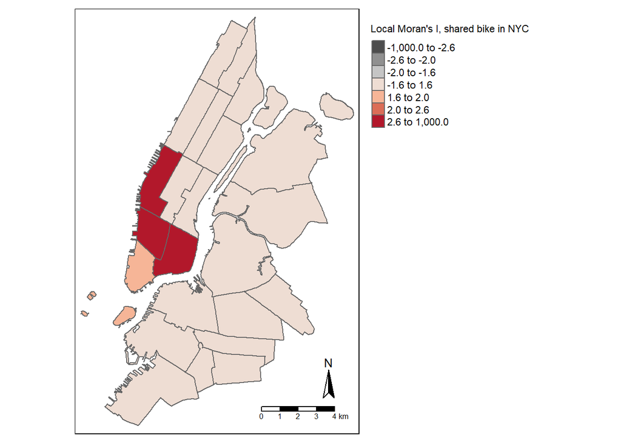

```r
#use the localmoran function to generate I for each ward in the city

I_CD_Local_count <- points_sf_joined %>%
  pull(count) %>%
  as.vector()%>%
  localmoran(., nyccd.nb)%>%
  as_tibble()

I_CD_Local_Density <- points_sf_joined %>%
  pull(density) %>%
  as.vector()%>%
  localmoran(., nyccd.nb)%>%
  as_tibble()

points_sf_joined <- points_sf_joined %>%
  mutate(bike_count_I = as.numeric(I_CD_Local_count$Ii))%>%
  mutate(bike_count_Iz =as.numeric(I_CD_Local_count$Z.Ii))%>%
  mutate(density_I =as.numeric(I_CD_Local_Density$Ii))%>%
  mutate(density_Iz =as.numeric(I_CD_Local_Density$Z.Ii))

breaks1<-c(-1000,-2.58,-1.96,-1.65,1.65,1.96,2.58,1000)
MoranColours<- rev(brewer.pal(8, "RdGy"))

tm_shape(points_sf_joined) +
  tm_polygons("bike_count_Iz",
              style="fixed",
              breaks=breaks1,
              palette=MoranColours,
              midpoint=NA,
              title="Local Moran's I, shared bike in NYC")+
  tm_compass(position = c("right", "bottom"))+
  tm_scale_bar(position = c("right", "bottom"))+
  tm_layout(legend.outside = TRUE)
```

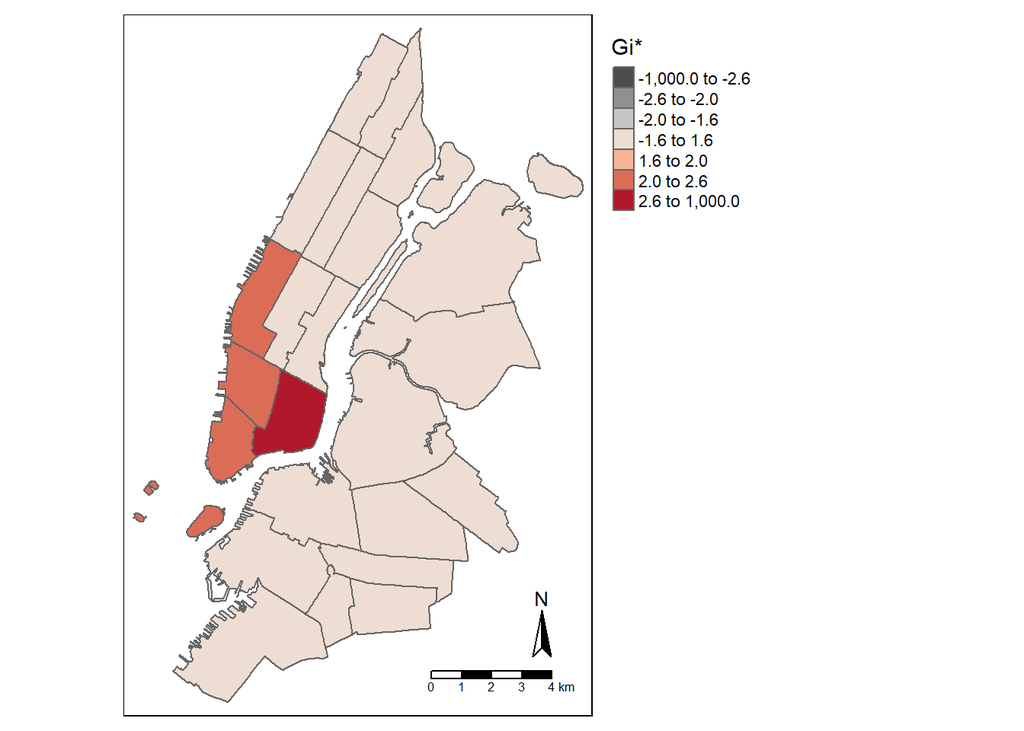

```r
                               ## Getis Ord  G∗i statisic for hot and cold spots
Gi_cd_Local_Density <- points_sf_joined %>%
  pull(density) %>%
  as.vector()%>%
  localG(., nyccd.nb)
# head(Gi_cd_Local_Density)

points_sf_joined <- points_sf_joined %>%
  mutate(density_G = as.numeric(Gi_cd_Local_Density))

GIColours<- rev(brewer.pal(8, "RdBu"))
#now plot on an interactive map

tm_shape(points_sf_joined) +
  tm_polygons("density_G",
              style="fixed",
              breaks=breaks1,
              palette=MoranColours,
              midpoint=NA,
              title="Gi*")+
  tm_compass(position = c("right", "bottom"))+
  tm_scale_bar(position = c("right", "bottom"))+
  tm_layout(legend.outside = TRUE)
```

we can see there are some clustrering in the two plot, but what make this happened? or is there any factors affect the travel patterns?

# Regression analysis

to answer “why” we can do some regression analysis. first load the facilities file

```r
nyfc <- read_csv(("https://opendata.arcgis.com/datasets/620697560c3e4070a3623ac216b82ca6_0.csv"),
                 na = c("", "NA", "n/a"),
                 locale = locale(encoding = 'utf-8'),
                 col_names = TRUE)
```

```r
colnames(nyfc) <- colnames(nyfc) %>%
  str_to_lower() %>%
  str_replace_all(" ", "_")
#check all of the columns have been read in correctly
Datatypelist <- nyfc %>%
  summarise_all(class) %>%
  pivot_longer(everything(),
               names_to="All_variables",
               values_to="Variable_class")
Datatypelist
```

```
## # A tibble: 40 x 2
##    All_variables Variable_class
##    <chr>         <chr>
##  1 x             numeric
##  2 y             numeric
##  3 objectid      numeric
##  4 facname       character
##  5 addressnum    character
##  6 streetname    character
##  7 address       character
##  8 city          character
##  9 zipcode       numeric
## 10 boro          character
## # ... with 30 more rows
```

```r
#select the necessary columns
nyfc1 <- nyfc %>%
  dplyr::select(factype,facsubgrp,facgroup,facdomain,latitude,longitude)
# remove na in r - remove rows - na.omit function / option
nyfc1 <- na.omit(nyfc1)
```

now we just repeat what we’ve done to the bicycle sharing dataset, limit them into the map scope.

we also need to seperate the variables into seven types.

```r
# change to spatial data frame
nyfc1 <- st_as_sf(nyfc1, coords = c("longitude", "latitude"), crs = "WGS84")
nyfc1 <- nyfc1 %>%
  st_transform(.,crs="epsg:2263")
nyfc1 <- nyfc1[CDMap1boro,]

# making density map to standardize the variables.
fc_edu <- nyfc1 %>%
  filter(facdomain == "EDUCATION, CHILD WELFARE, AND YOUTH" )
fc_heal <- nyfc1 %>%
  filter(facdomain == "HEALTH AND HUMAN SERVICES" )
fc_park <- nyfc1 %>%
  filter(facdomain == "PARKS, GARDENS, AND HISTORICAL SITES" )
fc_tran <- nyfc1 %>%
  filter(facdomain == "CORE INFRASTRUCTURE AND TRANSPORTATION" )
fc_admin <- nyfc1 %>%
  filter(facdomain == "ADMINISTRATION OF GOVERNMENT" )
fc_publi <- nyfc1 %>%
  filter(facdomain == "PUBLIC SAFETY, EMERGENCY SERVICES, AND ADMINISTRATION OF JUSTICE" )
fc_lib <- nyfc1 %>%
  filter(facdomain == "LIBRARIES AND CULTURAL PROGRAMS" )
```

Next step is quite boring, we need to repeatly make the density of each independent variables.

```r
## edu file
gwrfc_edu <- CDMap1boro%>%
  st_join(fc_edu)%>%
  add_count(borocd)%>%
  janitor::clean_names()%>%
  mutate(area=st_area(.))%>%
  mutate(density=n/area)%>%
  dplyr::select(density, borocd, n)
gwrfc_edu<- gwrfc_edu %>%
  group_by(borocd) %>%
  summarise(density_edu = first(density),
            borocd= first(borocd),
            count_edu= first(n))
gwrfc_edu<- gwrfc_edu %>%
  st_drop_geometry()
gwrfc_edu$density_edu_scaled <- scale(gwrfc_edu$density_edu,center = FALSE, scale = TRUE)

## heal file
gwrfc_heal <- CDMap1boro%>%
  st_join(fc_heal)%>%
  add_count(borocd)%>%
  janitor::clean_names()%>%
  mutate(area=st_area(.))%>%
  mutate(density=n/area)%>%
  dplyr::select(density, borocd, n)
gwrfc_heal<- gwrfc_heal %>%
  group_by(borocd) %>%
  summarise(density_heal = first(density),
            borocd= first(borocd),
            count_heal= first(n))
gwrfc_heal<- gwrfc_heal %>%
  st_drop_geometry()
gwrfc_heal$density_heal_scaled <- scale(gwrfc_heal$density_heal,center = FALSE, scale = TRUE)

## tans file
gwrfc_tran <- CDMap1boro%>%
  st_join(fc_tran)%>%
  add_count(borocd)%>%
  janitor::clean_names()%>%
  mutate(area=st_area(.))%>%
  mutate(density=n/area)%>%
  dplyr::select(density, borocd, n)
gwrfc_tran<- gwrfc_tran %>%
  group_by(borocd) %>%
  summarise(density_tran = first(density),
            borocd= first(borocd),
            count_tran= first(n))
gwrfc_tran<- gwrfc_tran %>%
  st_drop_geometry()
gwrfc_tran$density_tran_scaled <- scale(gwrfc_tran$density_tran,center = FALSE, scale = TRUE)

## park file
gwrfc_park <- CDMap1boro%>%
  st_join(fc_park)%>%
  add_count(borocd)%>%
  janitor::clean_names()%>%
  mutate(area=st_area(.))%>%
  mutate(density=n/area)%>%
  dplyr::select(density, borocd, n)
gwrfc_park<- gwrfc_park %>%
  group_by(borocd) %>%
  summarise(density_park = first(density),
            borocd= first(borocd),
            count_park= first(n))
gwrfc_park<- gwrfc_park %>%
  st_drop_geometry()
gwrfc_park$density_park_scaled <- scale(gwrfc_park$density_park,center = FALSE, scale = TRUE)


## admin file
gwrfc_admin <- CDMap1boro%>%
  st_join(fc_admin)%>%
  add_count(borocd)%>%
  janitor::clean_names()%>%
  mutate(area=st_area(.))%>%
  mutate(density=n/area)%>%
  dplyr::select(density, borocd, n)
gwrfc_admin<- gwrfc_admin %>%
  group_by(borocd) %>%
  summarise(density_admin = first(density),
            borocd= first(borocd),
            count_admin= first(n))
gwrfc_admin<- gwrfc_admin %>%
  st_drop_geometry()
gwrfc_admin$density_admin_scaled <- scale(gwrfc_admin$density_admin,center = FALSE, scale = TRUE)

## public file
gwrfc_publi <- CDMap1boro%>%
  st_join(fc_publi)%>%
  add_count(borocd)%>%
  janitor::clean_names()%>%
  mutate(area=st_area(.))%>%
  mutate(density=n/area)%>%
  dplyr::select(density, borocd, n)
gwrfc_publi<- gwrfc_publi %>%
  group_by(borocd) %>%
  summarise(density_publi = first(density),
            borocd= first(borocd),
            count_publi= first(n))
gwrfc_publi<- gwrfc_publi %>%
  st_drop_geometry()
gwrfc_publi$density_publi_scaled <- scale(gwrfc_publi$density_publi,center = FALSE, scale = TRUE)


## library file
gwrfc_lib <- CDMap1boro%>%
  st_join(fc_lib)%>%
  add_count(borocd)%>%
  janitor::clean_names()%>%
  mutate(area=st_area(.))%>%
  mutate(density=n/area)%>%
  dplyr::select(density, borocd, n)
gwrfc_lib<- gwrfc_lib %>%
  group_by(borocd) %>%
  summarise(density_lib = first(density),
            borocd= first(borocd),
            count_lib= first(n))
gwrfc_lib<- gwrfc_lib %>%
  st_drop_geometry()
gwrfc_lib$density_lib_scaled <- scale(gwrfc_lib$density_lib,center = FALSE, scale = TRUE)

## join all data
gwrfc <- points_sf_joined%>%
  left_join(.,
            gwrfc_edu,
            by = c("borocd" = "borocd"))
gwrfc <- gwrfc%>%
  left_join(.,
            gwrfc_heal,
            by = c("borocd" = "borocd"))
gwrfc <- gwrfc%>%
  left_join(.,
            gwrfc_tran,
            by = c("borocd" = "borocd"))
gwrfc <- gwrfc%>%
  left_join(.,
            gwrfc_park,
            by = c("borocd" = "borocd"))
gwrfc <- gwrfc%>%
  left_join(.,
            gwrfc_publi,
            by = c("borocd" = "borocd"))
gwrfc <- gwrfc%>%
  left_join(.,
            gwrfc_admin,
            by = c("borocd" = "borocd"))
gwrfc <- gwrfc%>%
  left_join(.,
            gwrfc_lib,
            by = c("borocd" = "borocd"))
colnames(gwrfc)
```

```
##  [1] "borocd"               "density"              "count"
##  [4] "geometry"             "density_scaled"       "bike_count_I"
##  [7] "bike_count_Iz"        "density_I"            "density_Iz"
## [10] "density_G"            "density_edu"          "count_edu"
## [13] "density_edu_scaled"   "density_heal"         "count_heal"
## [16] "density_heal_scaled"  "density_tran"         "count_tran"
## [19] "density_tran_scaled"  "density_park"         "count_park"
## [22] "density_park_scaled"  "density_publi"        "count_publi"
## [25] "density_publi_scaled" "density_admin"        "count_admin"
## [28] "density_admin_scaled" "density_lib"          "count_lib"
## [31] "density_lib_scaled"
```

Now we can plot them for a glance.

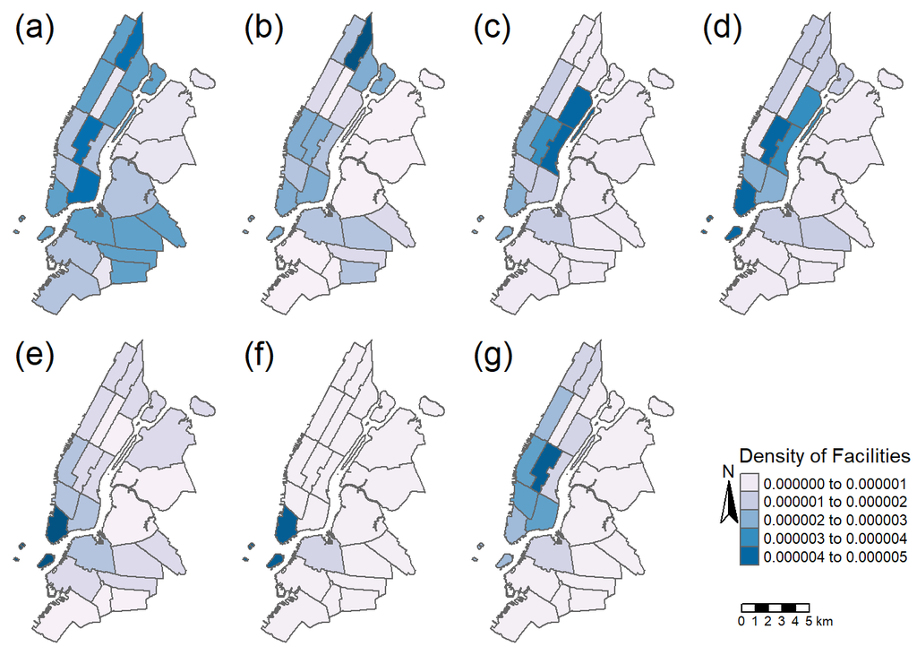

```r
# plot each map
tmap_mode("plot")
tm1 <- tm_shape(gwrfc) +
  tm_polygons("density_edu",
              palette="PuBu")+
  tm_legend(show=FALSE)+
  tm_layout(frame=FALSE)+
  tm_credits("(a)", position=c(0,0.85), size=1.5)

tm2 <- tm_shape(gwrfc) +
  tm_polygons("density_heal",
              palette="PuBu") +
  tm_legend(show=FALSE)+
  tm_layout(frame=FALSE)+
  tm_credits("(b)", position=c(0,0.85), size=1.5)
tm3 <- tm_shape(gwrfc) +
  tm_polygons("density_tran",
              palette="PuBu") +
  tm_legend(show=FALSE)+
  tm_layout(frame=FALSE)+
  tm_credits("(c)", position=c(0,0.85), size=1.5)
tm4 <- tm_shape(gwrfc)+
  tm_polygons("density_park",
              palette="PuBu")+
  tm_legend(show=FALSE)+
  tm_layout(frame=FALSE)+
  tm_credits("(d)", position=c(0,0.85), size=1.5)

tm5 <- tm_shape(gwrfc)+
  tm_polygons("density_publi",
              palette="PuBu")+
  tm_legend(show=FALSE)+
  tm_layout(frame=FALSE)+
  tm_credits("(e)", position=c(0,0.85), size=1.5)

tm6 <- tm_shape(gwrfc)+
  tm_polygons("density_admin",
              palette="PuBu")+
  tm_legend(show=FALSE)+
  tm_layout(frame=FALSE)+
  tm_credits("(f)", position=c(0,0.85), size=1.5)

tm7 <- tm_shape(gwrfc)+
  tm_polygons("density_lib",
              palette="PuBu")+
  tm_legend(show=FALSE)+
  tm_layout(frame=FALSE)+
  tm_credits("(g)", position=c(0,0.85), size=1.5)

legend <- tm_shape(gwrfc) +
  tm_polygons("density_park",
              palette="PuBu",
              title = "Density of Facilities") +
  tm_scale_bar(position=c(0.2,0.04), text.size=0.6)+
  tm_compass(north=0, position=c(0.025,0.4))+
  tm_layout(legend.only = TRUE, legend.position=c(0.2,0.25),asp=0.1)

t=tmap_arrange(tm1, tm2, tm3,tm4,tm5,tm6,tm7, legend, ncol=4)

t
```

take a look at the correlation of dependent and independent variables by using scatter plot. I will only do it once, but we can check all the cases by change the x name.

REMEMBER, using the scaled number for regression analysis!

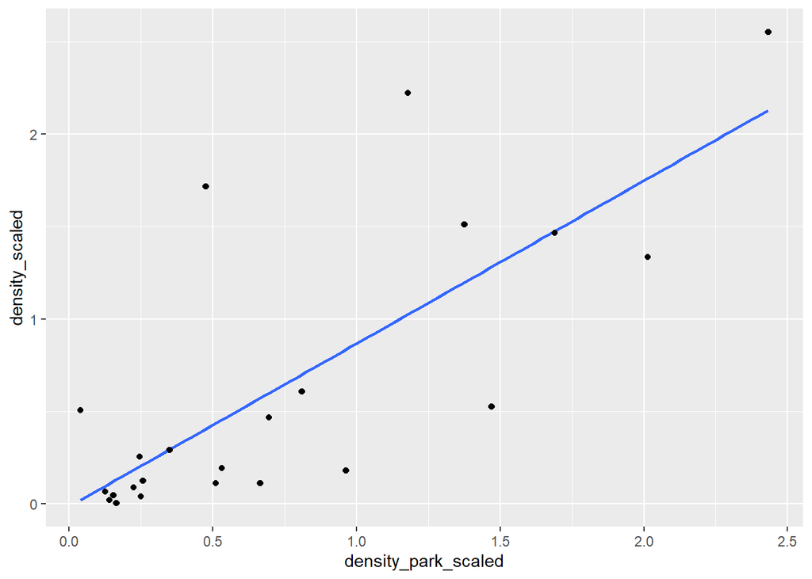

```r
#plot with a regression line - note, I've added some jitter here as the x-scale is rounded
q <- qplot(x = `density_park_scaled`,
           y = `density_scaled`,
           data=gwrfc)
q + stat_smooth(method="lm", se=FALSE, size=1) +
  geom_jitter()
```

## OLS model

Let’s firstly make the OLS model

DO NOT forget to do the vif after the OLS analysis, in my case, I found “density_publi_scaled” and “density_lib_scaled” has extremely high multicollinearity. so I removed it in the final model.

```r
#select some variables from the data file
gwrfc_1 <- gwrfc %>%
  dplyr::select(density_scaled,
                density_edu_scaled,
                density_heal_scaled,
                density_tran_scaled,
                density_park_scaled,
                density_publi_scaled,
                density_admin_scaled,
                density_lib_scaled)

#run a final OLS model
model_final <- lm(density_scaled ~
                  density_edu_scaled+
                  density_heal_scaled+
                  density_tran_scaled+
                  density_park_scaled+
                  density_admin_scaled,
                  data = gwrfc_1)
vif(model_final)
```

```
##   density_edu_scaled  density_heal_scaled  density_tran_scaled
##             4.480833             4.498743             2.683225
##  density_park_scaled density_admin_scaled
##             4.316934             1.409686
```

```r
tidy(model_final)
```

```
## # A tibble: 6 x 5
##   term                 estimate std.error statistic p.value
##   <chr>                   <dbl>     <dbl>     <dbl>   <dbl>
## 1 (Intercept)            0.227      0.272     0.834  0.416
## 2 density_edu_scaled    -0.678      0.522    -1.30   0.211
## 3 density_heal_scaled    0.437      0.413     1.06   0.304
## 4 density_tran_scaled    0.0777     0.253     0.307  0.763
## 5 density_park_scaled    0.944      0.345     2.74   0.0140
## 6 density_admin_scaled  -0.163      0.166    -0.979  0.342
```

```r
summary(model_final)
```

```
##
## Call:
## lm(formula = density_scaled ~ density_edu_scaled + density_heal_scaled +
##     density_tran_scaled + density_park_scaled + density_admin_scaled,
##     data = gwrfc_1)
##
## Residuals:
##      Min       1Q   Median       3Q      Max
## -0.85485 -0.19721 -0.03142  0.19099  1.06639
##
## Coefficients:
##                      Estimate Std. Error t value Pr(>|t|)
## (Intercept)           0.22674    0.27202   0.834    0.416
## density_edu_scaled   -0.67849    0.52246  -1.299    0.211
## density_heal_scaled   0.43742    0.41270   1.060    0.304
## density_tran_scaled   0.07772    0.25333   0.307    0.763
## density_park_scaled   0.94352    0.34472   2.737    0.014 *
## density_admin_scaled -0.16290    0.16647  -0.979    0.342
## ---
## Signif. codes:  0 '***' 0.001 '**' 0.01 '*' 0.05 '.' 0.1 ' ' 1
##
## Residual standard error: 0.5191 on 17 degrees of freedom
## Multiple R-squared:  0.6455, Adjusted R-squared:  0.5413
## F-statistic: 6.192 on 5 and 17 DF,  p-value: 0.001918
```

```r
glance(model_final)
```

```
## # A tibble: 1 x 12
##   r.squared adj.r.squared sigma statistic p.value    df logLik   AIC   BIC
##       <dbl>         <dbl> <dbl>     <dbl>   <dbl> <dbl>  <dbl> <dbl> <dbl>
## 1     0.646         0.541 0.519      6.19 0.00192     5  -14.1  42.2  50.1
## # ... with 3 more variables: deviance <dbl>, df.residual <int>, nobs <int>
```

```r
anova(model_final)
```

```
## Analysis of Variance Table
##
## Response: density_scaled
##                      Df Sum Sq Mean Sq F value   Pr(>F)
## density_edu_scaled    1 1.4096  1.4096  5.2315 0.035273 *
## density_heal_scaled   1 1.1862  1.1862  4.4025 0.051136 .
## density_tran_scaled   1 3.7163  3.7163 13.7928 0.001725 **
## density_park_scaled   1 1.7711  1.7711  6.5733 0.020127 *
## density_admin_scaled  1 0.2580  0.2580  0.9576 0.341518
## Residuals            17 4.5805  0.2694
## ---
## Signif. codes:  0 '***' 0.001 '**' 0.01 '*' 0.05 '.' 0.1 ' ' 1
```

```r
AICc(model_final)
```

```
## [1] 47.40625
```

Let’s check the model fitness and residuals correlation

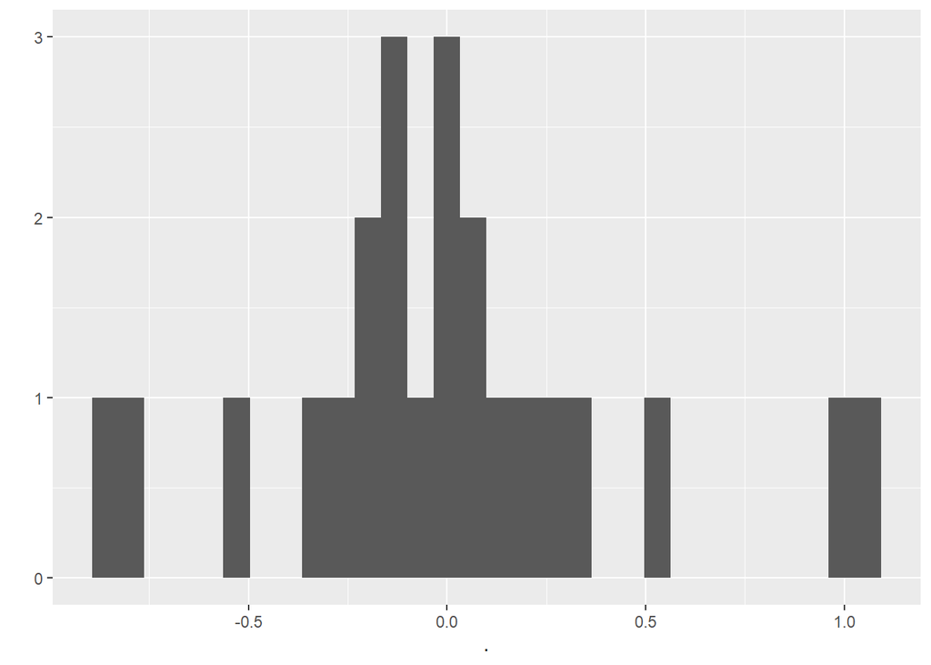

```r
##residuals
model_data <- model_final %>%
  augment(., gwrfc_1)
#plot residuals
model_data%>%
  dplyr::select(.resid)%>%
  pull()%>%
  qplot()+
  geom_histogram(binwidth = 0.01)
```

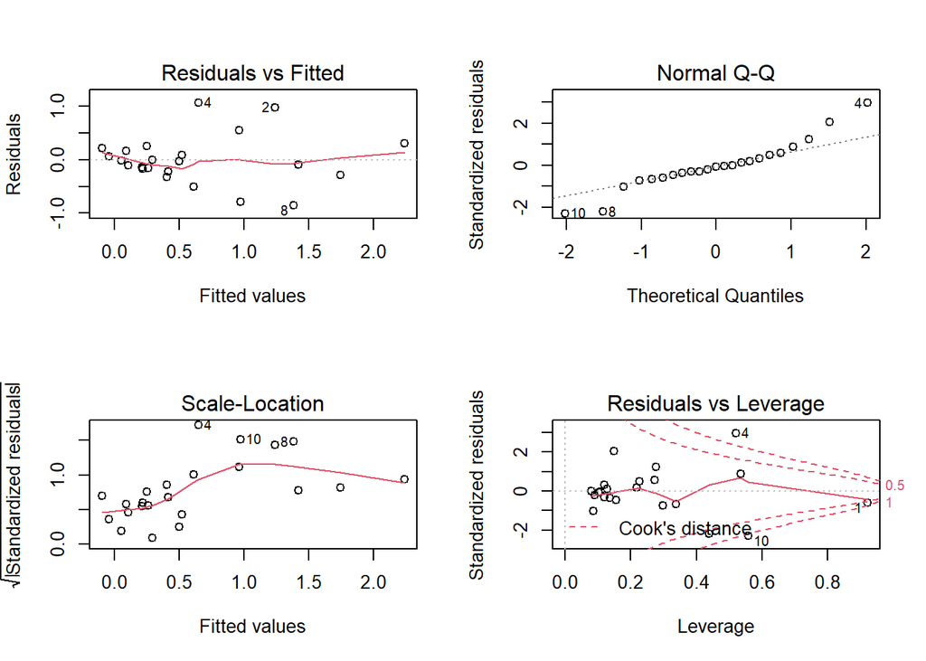

```r
gwrfc_1 <- gwrfc_1 %>%
  mutate(modelOLSresids = residuals(model_final))

#print some model diagnositcs.
par(mfrow=c(2,2))    #plot to 2 by 2 array
plot(model_final)
```

```r
#now plot the residuals
tmap_mode("view")
qtm(gwrfc_1, fill = "modelOLSresids")
```

[interactive chart not shown]

```r
#knn
knn_nyccd <-coordsW %>%
  knearneigh(., k=4)
nyccd_knn <- knn_nyccd %>%
  knn2nb()
nyccd_knn_weight <- nyccd_knn %>%
  nb2listw(., style="C")
#queen
nyccd_nb_weight <- nyccd_nb %>%
  nb2listw(., style="C")

Queen  <- gwrfc_1 %>%
  st_drop_geometry()%>%
  dplyr::select(modelOLSresids)%>%
  pull()%>%
  moran.test(., nyccd_nb_weight)%>%
  tidy()
Nearest_neighbour <- gwrfc_1 %>%
  st_drop_geometry()%>%
  dplyr::select(modelOLSresids)%>%
  pull()%>%
  moran.test(., nyccd_knn_weight)%>%
  tidy()
Queen
```

```
## # A tibble: 1 x 7
##   estimate1 estimate2 estimate3 statistic p.value method             alternative
##       <dbl>     <dbl>     <dbl>     <dbl>   <dbl> <chr>              <chr>
## 1     0.409   -0.0455    0.0334      2.49 0.00643 Moran I test unde~ greater
```

```r
Nearest_neighbour
```

```
## # A tibble: 1 x 7
##   estimate1 estimate2 estimate3 statistic p.value method             alternative
##       <dbl>     <dbl>     <dbl>     <dbl>   <dbl> <chr>              <chr>
## 1    0.0809   -0.0455    0.0147      1.04   0.149 Moran I test unde~ greater
```

From here we can find that the residuals lost its spatial autocorrelation when it comes to KNN method of neighbouring, but in queen’s method case it still remained, let’s try some other models

## Sptial lag regression

when can do the SLM to check the time’s impact.

```r
#spatial lag regre
model_final2queen <- lagsarlm(density_scaled ~
                                density_edu_scaled+
                                density_heal_scaled+
                                density_tran_scaled+
                                density_park_scaled+
                                density_admin_scaled,
                                data = gwrfc_1,
                                nb2listw(nyccd_nb, style="C"),
                                method = "eigen")
tidy(model_final2queen)
```

```
## # A tibble: 7 x 5
##   term                 estimate std.error statistic p.value
##   <chr>                   <dbl>     <dbl>     <dbl>   <dbl>
## 1 rho                    0.314      0.112     2.81  0.00502
## 2 (Intercept)            0.0663     0.213     0.311 0.756
## 3 density_edu_scaled    -0.450      0.396    -1.14  0.256
## 4 density_heal_scaled    0.286      0.312     0.915 0.360
## 5 density_tran_scaled    0.0958     0.190     0.505 0.614
## 6 density_park_scaled    0.797      0.261     3.05  0.00227
## 7 density_admin_scaled  -0.193      0.125    -1.55  0.121
```

```r
summary(model_final2queen)
```

```
##
## Call:spatialreg::lagsarlm(formula = formula, data = data, listw = listw,
##     na.action = na.action, Durbin = Durbin, type = type, method = method,
##     quiet = quiet, zero.policy = zero.policy, interval = interval,
##     tol.solve = tol.solve, trs = trs, control = control)
##
## Residuals:
##       Min        1Q    Median        3Q       Max
## -0.872897 -0.144941 -0.002535  0.133308  0.971001
##
## Type: lag
## Coefficients: (asymptotic standard errors)
##                       Estimate Std. Error z value Pr(>|z|)
## (Intercept)           0.066278   0.213448  0.3105 0.756173
## density_edu_scaled   -0.449597   0.396037 -1.1352 0.256275
## density_heal_scaled   0.285750   0.312199  0.9153 0.360043
## density_tran_scaled   0.095784   0.189681  0.5050 0.613576
## density_park_scaled   0.796946   0.261045  3.0529 0.002266
## density_admin_scaled -0.193171   0.124642 -1.5498 0.121186
##
## Rho: 0.31387, LR test value: 5.282, p-value: 0.021547
## Asymptotic standard error: 0.11186
##     z-value: 2.806, p-value: 0.0050164
## Wald statistic: 7.8735, p-value: 0.0050164
##
## Log likelihood: -11.43714 for lag model
## ML residual variance (sigma squared): 0.1505, (sigma: 0.38795)
## Number of observations: 23
## Number of parameters estimated: 8
## AIC: 38.874, (AIC for lm: 42.156)
## LM test for residual autocorrelation
## test value: 4.2108, p-value: 0.040168
```

```r
glance(model_final2queen)
```

```
## # A tibble: 1 x 6
##   r.squared   AIC   BIC deviance logLik  nobs
##       <dbl> <dbl> <dbl>    <dbl>  <dbl> <int>
## 1     0.732  38.9  48.0     3.46  -11.4    23
```

```r
anova(model_final2queen)
```

```
##                      AIC Log.likelihood df
## model_final2queen 38.874        -11.437  8
```

```r
AICc(model_final2queen)
```

```
## [1] 46.34094
```

better than OLS, but not that obviouse, let’s check the residuals spatial autocorrelation

```r
gwrfc_1 <- gwrfc_1 %>%
  mutate(slag_dv_model2_queen_resids = residuals(model_final2queen))
queenMoran <- gwrfc_1 %>%
  st_drop_geometry()%>%
  dplyr::select(slag_dv_model2_queen_resids)%>%
  pull()%>%
  moran.test(., nyccd_nb_weight)%>%
  tidy()
queenMoran
```

```
## # A tibble: 1 x 7
##   estimate1 estimate2 estimate3 statistic p.value method             alternative
##       <dbl>     <dbl>     <dbl>     <dbl>   <dbl> <chr>              <chr>
## 1     0.322   -0.0455    0.0329      2.03  0.0214 Moran I test unde~ greater
```

well, the autocorrelation still remain in 0.05 level, maybe time did not affect much, let’s check other model.

## spatial error model

What about spatial error model?

```r
#spatial error regre
model_final3 <- errorsarlm(density_scaled ~
                             density_edu_scaled+
                             density_heal_scaled+
                             density_tran_scaled+
                             density_park_scaled+
                             density_admin_scaled,
                           data = gwrfc_1,
                         nb2listw(nyccd_nb, style="C"),
                         method = "eigen")
tidy(model_final3)
```

```
## # A tibble: 7 x 5
##   term                 estimate std.error statistic  p.value
##   <chr>                   <dbl>     <dbl>     <dbl>    <dbl>
## 1 (Intercept)             0.508    0.197      2.59  0.00968
## 2 density_edu_scaled     -0.303    0.241     -1.26  0.209
## 3 density_heal_scaled     0.165    0.199      0.830 0.406
## 4 density_tran_scaled     0.219    0.143      1.53  0.127
## 5 density_park_scaled     0.664    0.186      3.57  0.000359
## 6 density_admin_scaled   -0.302    0.0805    -3.76  0.000171
## 7 lambda                  0.689    0.0681    10.1   0
```

```r
summary(model_final3)
```

```
##
## Call:spatialreg::errorsarlm(formula = formula, data = data, listw = listw,
##     na.action = na.action, Durbin = Durbin, etype = etype, method = method,
##     quiet = quiet, zero.policy = zero.policy, interval = interval,
##     tol.solve = tol.solve, trs = trs, control = control)
##
## Residuals:
##       Min        1Q    Median        3Q       Max
## -0.762859 -0.185073 -0.077926  0.118242  0.557082
##
## Type: error
## Coefficients: (asymptotic standard errors)
##                       Estimate Std. Error z value  Pr(>|z|)
## (Intercept)           0.508468   0.196552  2.5869 0.0096832
## density_edu_scaled   -0.302926   0.241045 -1.2567 0.2088549
## density_heal_scaled   0.165264   0.199091  0.8301 0.4064862
## density_tran_scaled   0.218779   0.143439  1.5252 0.1272004
## density_park_scaled   0.663625   0.185985  3.5682 0.0003595
## density_admin_scaled -0.302407   0.080471 -3.7579 0.0001713
##
## Lambda: 0.68881, LR test value: 12.487, p-value: 0.00040982
## Asymptotic standard error: 0.068124
##     z-value: 10.111, p-value: < 2.22e-16
## Wald statistic: 102.23, p-value: < 2.22e-16
##
## Log likelihood: -7.834696 for error model
## ML residual variance (sigma squared): 0.081219, (sigma: 0.28499)
## Number of observations: 23
## Number of parameters estimated: 8
## AIC: 31.669, (AIC for lm: 42.156)
```

```r
glance(model_final3)
```

```
## # A tibble: 1 x 6
##   r.squared   AIC   BIC deviance logLik  nobs
##       <dbl> <dbl> <dbl>    <dbl>  <dbl> <int>
## 1     0.871  31.7  40.8     1.87  -7.83    23
```

```r
anova(model_final3)
```

```
##                 AIC Log.likelihood df
## model_final3 31.669        -7.8347  8
```

```r
AICc(model_final3)
```

```
## [1] 39.13606
```

Much better! And the Moran’s I of residuals?

```r
gwrfc_1 <- gwrfc_1 %>%
  mutate(ser_dv_model3_queen_resids = residuals(model_final3))
queenMoran2 <- gwrfc_1 %>%
  st_drop_geometry()%>%
  dplyr::select(ser_dv_model3_queen_resids)%>%
  pull()%>%
  moran.test(., nyccd_nb_weight)%>%
  tidy()
queenMoran2
```

```
## # A tibble: 1 x 7
##   estimate1 estimate2 estimate3 statistic p.value method             alternative
##       <dbl>     <dbl>     <dbl>     <dbl>   <dbl> <chr>              <chr>
## 1     0.163   -0.0455    0.0337      1.13   0.129 Moran I test unde~ greater
```

```r
#now plot the residuals
tmap_mode("view")
qtm(gwrfc_1, fill = "ser_dv_model3_queen_resids")
```

[interactive chart not shown]

it seems that SEM completely elimated the Spatial autocorrelation issue, and model fit indexes are much more better.